# xYAF: A metric to evaluate punt returns in the NFL

12/7/2021

## Background - “Expected” metrics

- In sports analytics, “expected” metrics are used to evaluate player or team performance
  - Soccer: Expected goals (xG) \(^{[1]}\), expected assists, expected points
  - Basketball: Expected points, expected possession value \(^{[2]}\)
  - Football: Expected Yards after Catch \(^{[3]}\)
- Many uses for these metrics
  - Compare a player’s output to an objective baseline
  - Evaluate a team’s performance by eliminating randomness

## Expected Yards After Fielding (xYAF)

- Given the current conditions when fielding a punt, how many yards do we expect the punt returner to gain
- Takes into account
  - Punt position
  - Fielding position
  - All defender positions (relative)
  - Punt hang time
- Should return an accurate estimate of how many yards the player gains based on these factors

## Model Evaluations

## Linear Regression

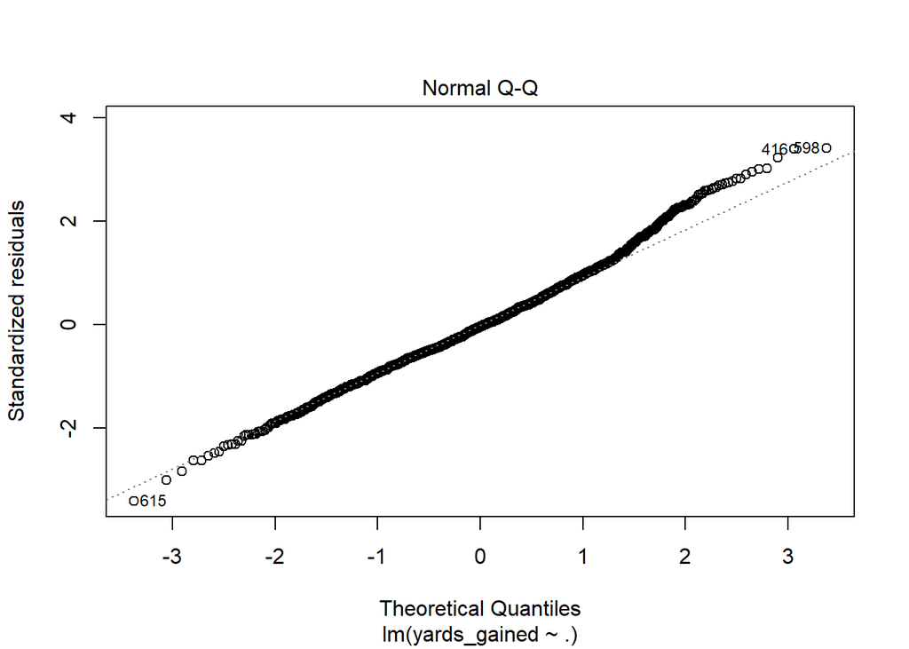

## Linear Regression

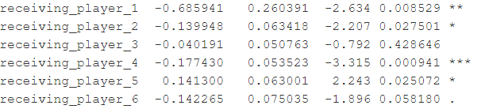

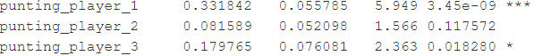

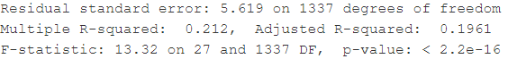

## Linear Regression

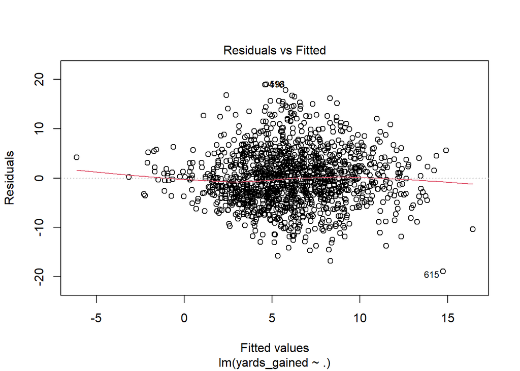

## Logistic Regression

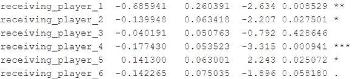

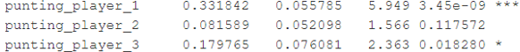

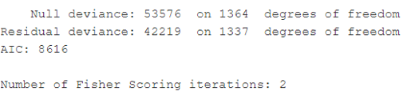

## Best Subset Selection (Forward, Backward)

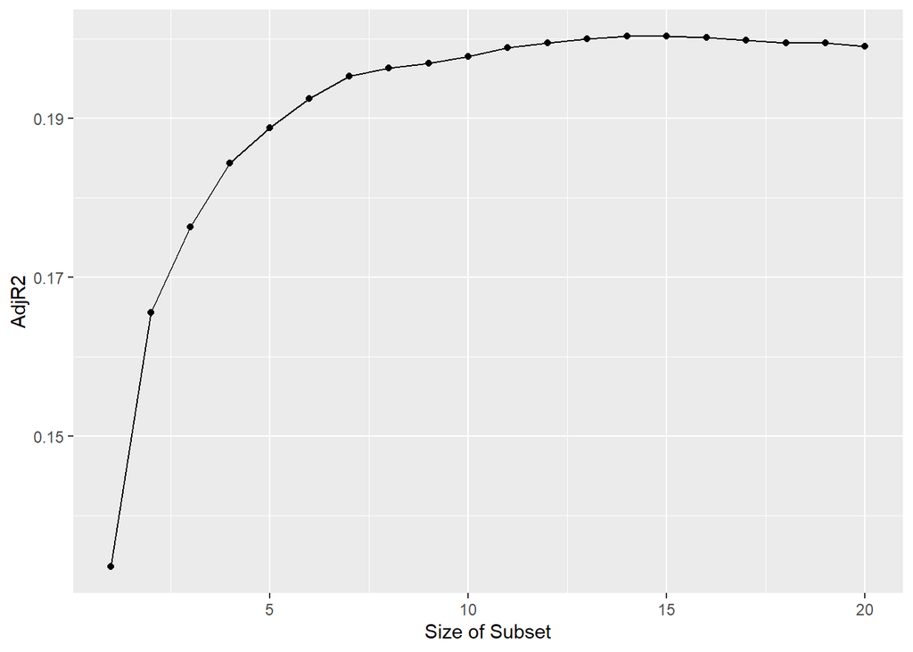

Forward Subset Selection

## Best Subset Selection (Forward, Backward)

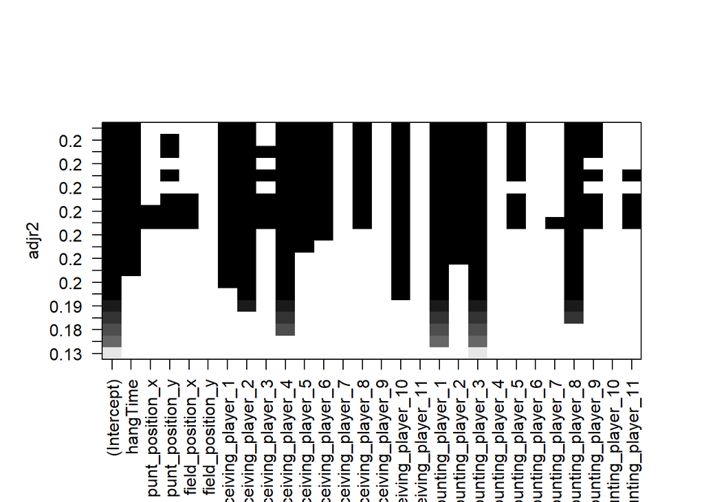

Forward Variable Selection

## Best Subset Selection (Forward, Backward)

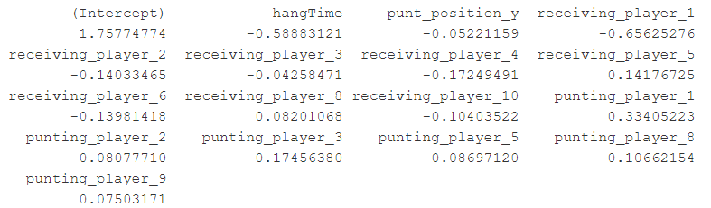

Forward Variable Selection

## Best Subset Selection (Forward, Backward)

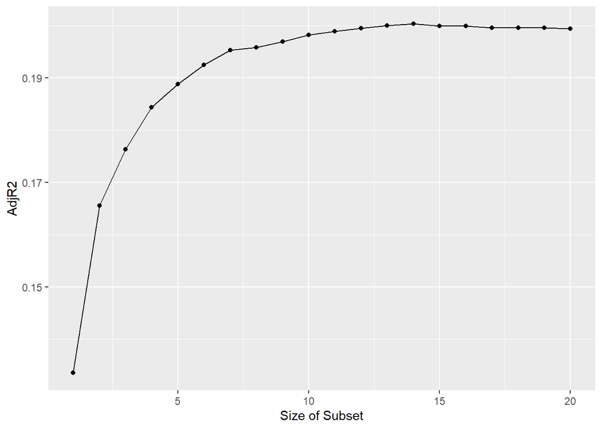

Backward

## Best Subset Selection (Forward, Backward)

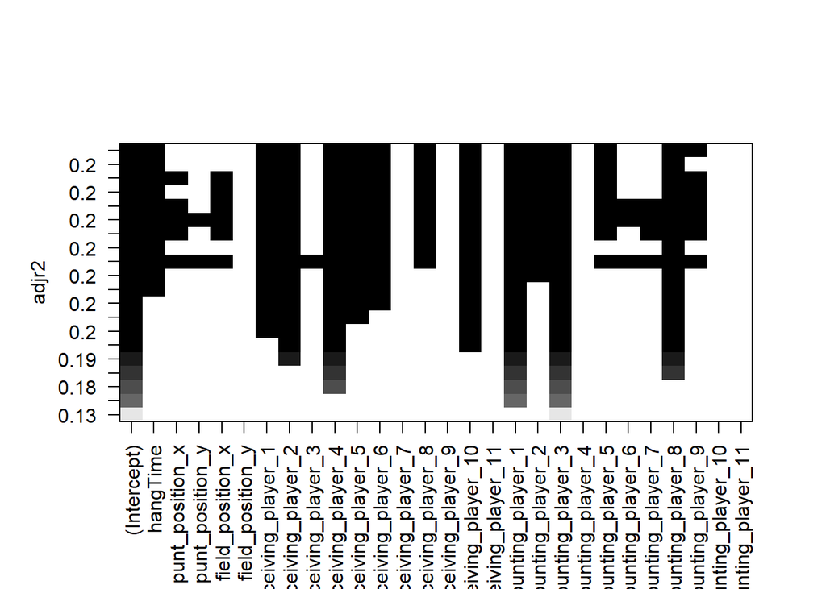

Backward Variable Selection

## Best Subset Selection (Forward, Backward)

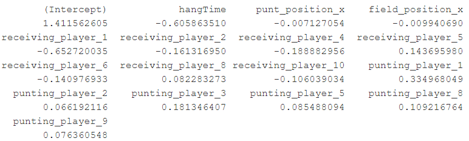

Backward Variable Selection

## Random Forests

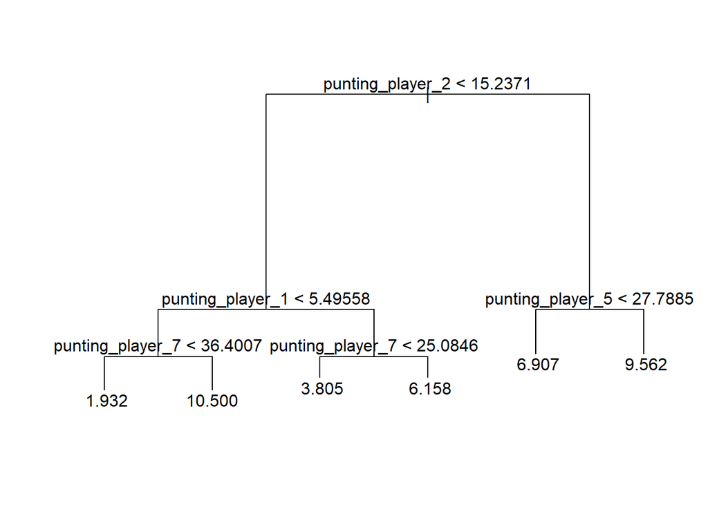

## Random Forests

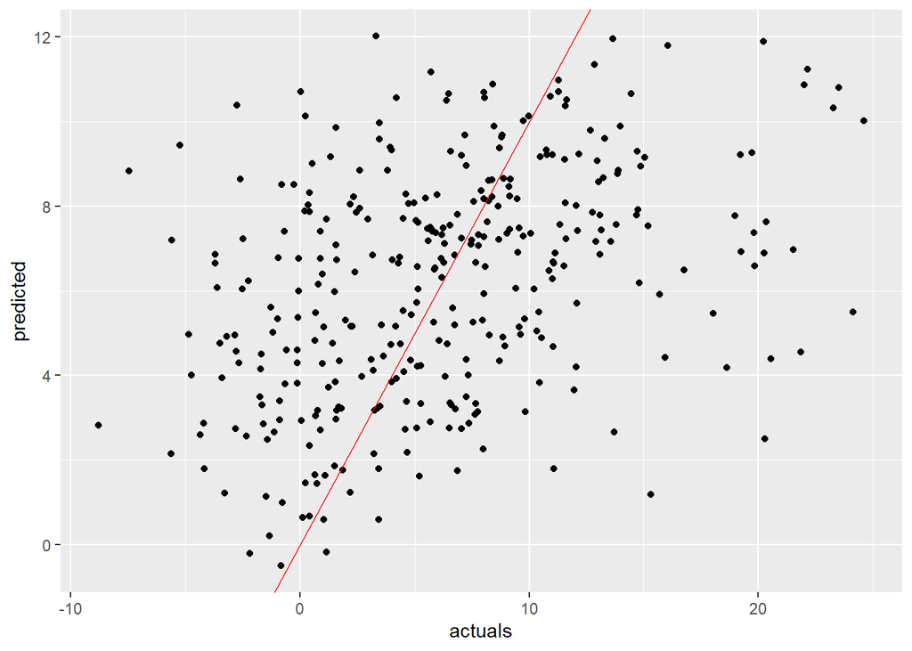

## Random Forests

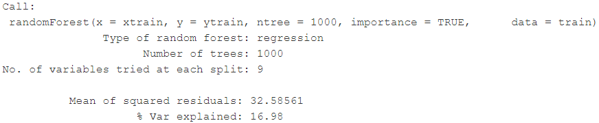

## LASSO/Ridge Regression

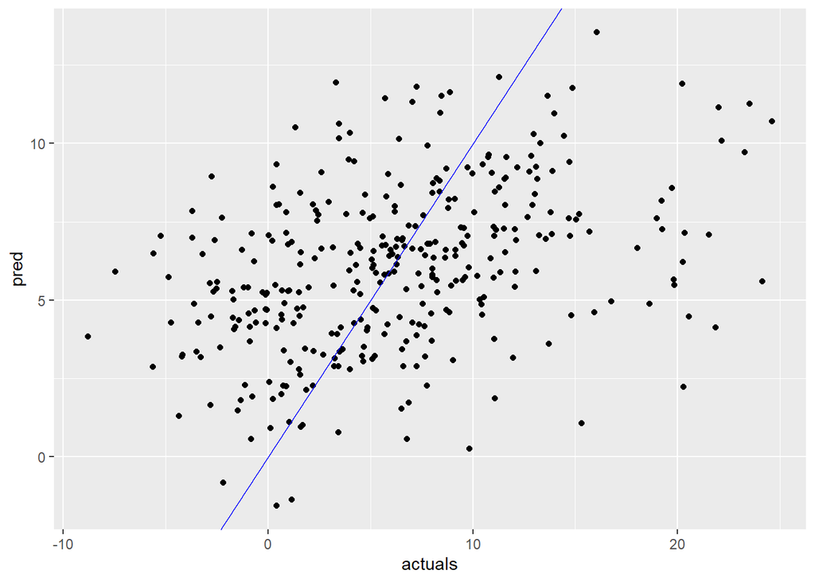

Actual vs Predicted Lasso

## GAMs

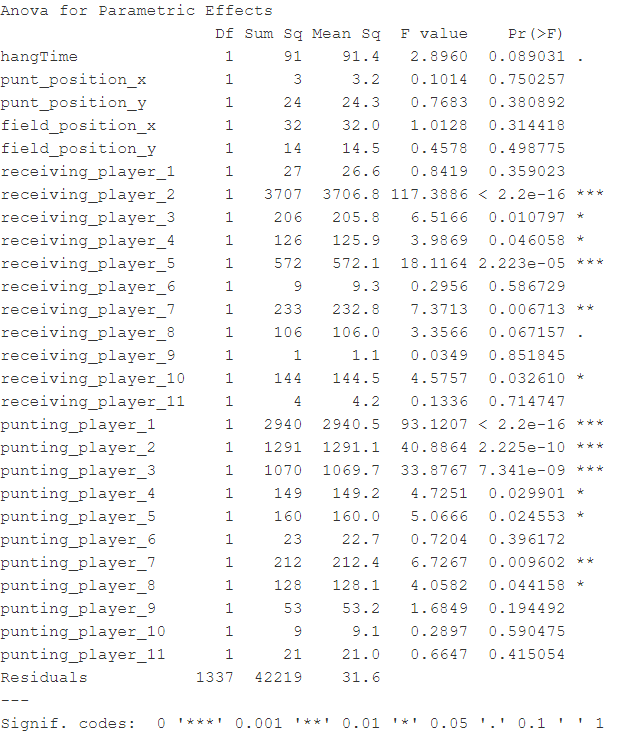

GAM Model

## GAM

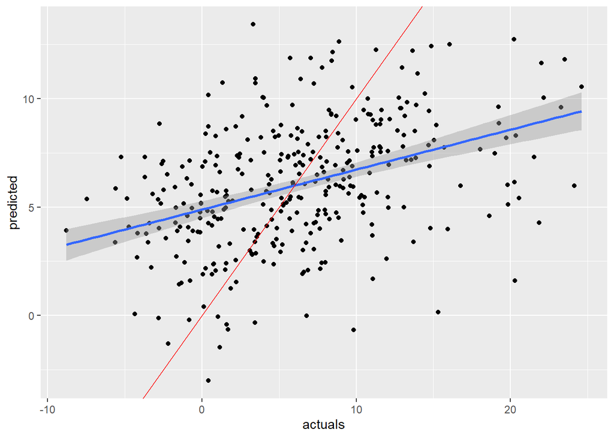

Actual vs Predicted

## Splines

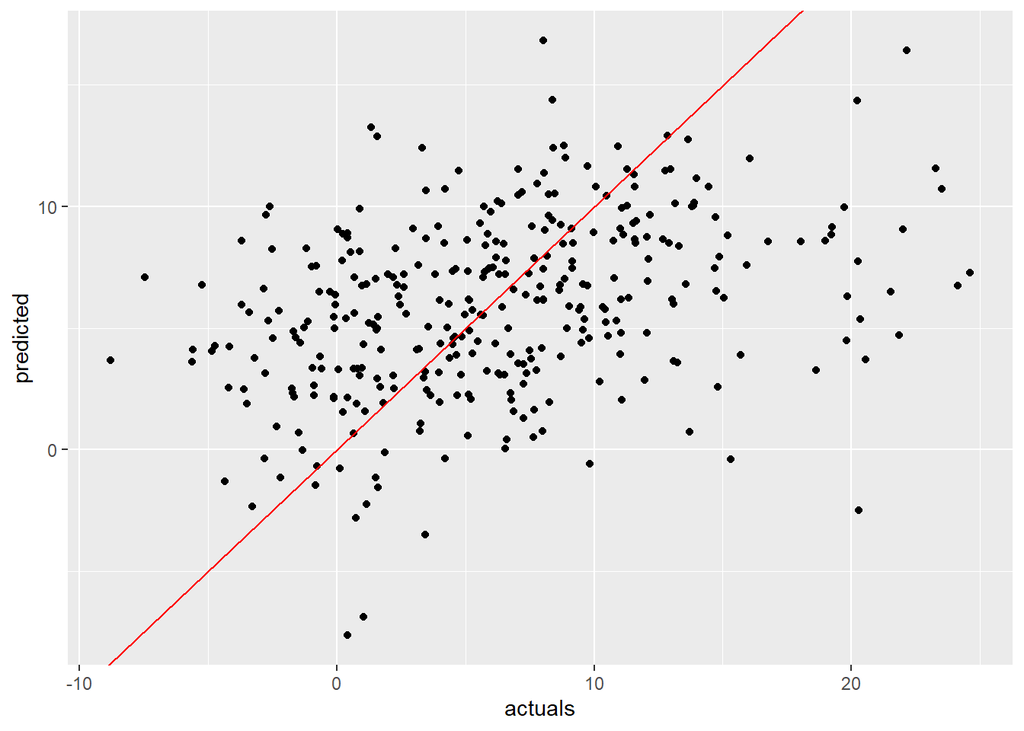

Actual vs Predicted

## Boosting

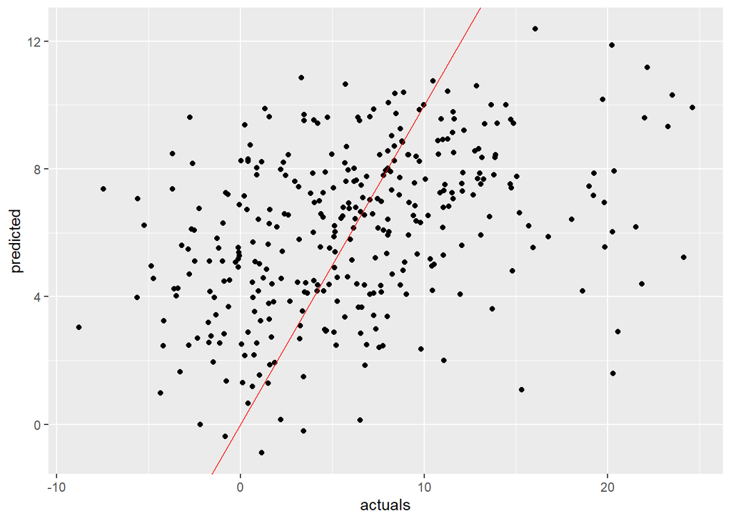

Actual vs Predicted

## Model Comparison

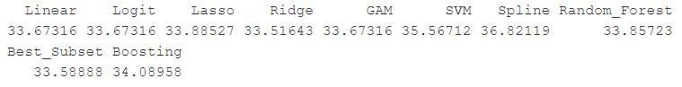

MSEs

## Evaluation and Conclusion

## Evaluation

Problem: Some methods assume normally distributed data

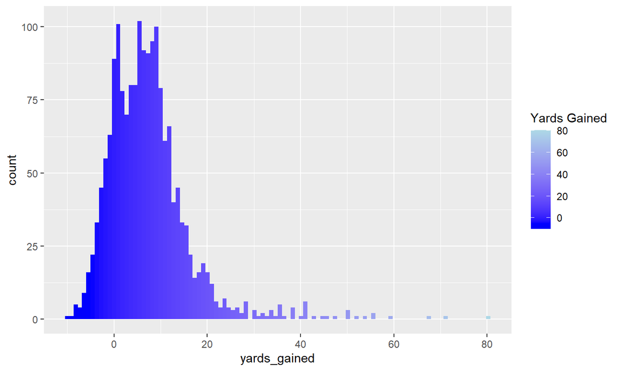

## Evaluation

Possible solution: Variable Transforms

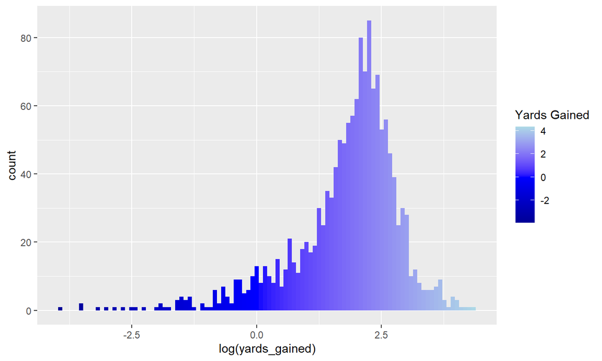

## Evaluation

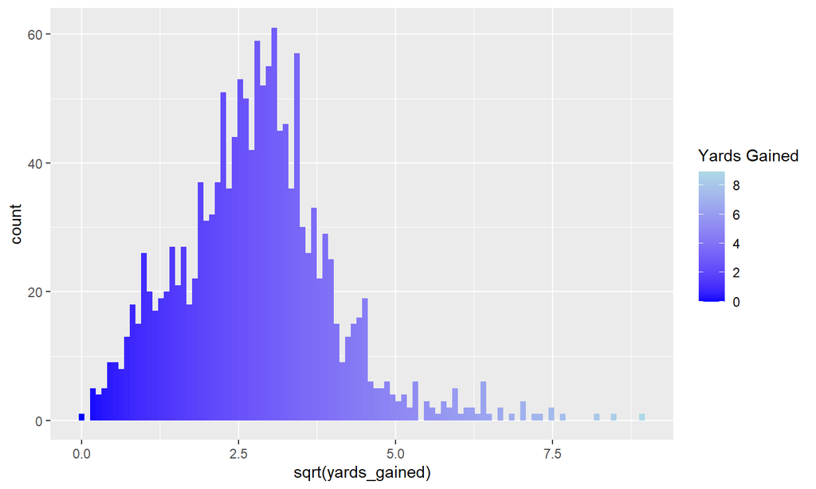

Better, but also doesn’t handle negative values.

## Examples

[figure not shown]

An 85 yard punt return by Diontae Johnson

## Examples

[figure not shown]

A 2 yard punt return by Richie James Jr.

## Works Cited

[1] Sam Green. Assessing the performance of Premier League goalscorers. Stats Perform, 2012.

[2] https://grantland.com/features/expected-value-possession-nba-analytics/

[3] https://www.nfl.com/news/next-gen-stats-intro-to-expected-yards-after-catch-0ap3000000983644

[4] Peng et. al., A Defensive Player Coverage Evaluation Framework, https://www.kaggle.com/model284/a-defensive-player-coverage-evaluation-framework